# SNA Betwenness Vertex 2_RELACIONAMENTO FORMAL (var0)

Leonardo Martins

17 de julho de 2016

SNA Descritive Analysis from “Projeto Redes de Atenção às pessoas que consomem álcool e outras Drogas em Juiz de Fora-MG Brazil” - SNArRDJF

Here you can find a basic script to analysis data from SNArRDJF - this script was elaborated considering its use for orther matrix adjacency data from SNArRDJF - Here we are going to analyse:

# 1 2_RELACIONAMENTO FORMAL (var0)

# 2 Loading objects generated with previous script

```r
rm(list = ls()) # removing previous objects to be sure that we don't have objects conflicts name
load("~/SNArRDJF/Robject/var0_data.RData")
```

## 2.1 Reload packages

```r
suppressMessages(library(RColorBrewer))
#suppressMessages(library(car))
#suppressMessages(library(xtable))
suppressMessages(library(igraph))
#suppressMessages(library(miniCRAN))
#suppressMessages(library(magrittr))
#suppressMessages(library(keyplayer))
suppressMessages(library(dplyr))
#suppressMessages(library(feather))
#suppressMessages(library(visNetwork))
#suppressMessages(library(knitr))
suppressMessages(library(DT))
```

## 2.2 Adding phantom tools

```r
#In order to get dinamic javascript object install those ones. If you get problems installing go to Stackoverflow.com and type your error to discover what to do. In some cases the libraries need to be intalled in outside R libs.
#devtools::install_github("wch/webshot")
#webshot::install_phantomjs()
```

## 2.3 Setting a random seed - this is a good strategy to keep the same graph pattern layout in a new report generation

```r
set.seed(123)
```

## 2.4 Simplify Graph - removing loops and duble edges

```r
#var0<-simplify(var0) #Simplify
```

# 3 Betweenness - Number of shortest paths going through the actor σst(i)

High betweenness centrality - vertex lies on many shortest paths. Probability that a communication from s to t will go through i - considering σst(i).

Betweenness measures the number of shortest paths between nodes in the network that go through the node in question. Nodes with relatively high betweenness are likely to be key conduits of information flow across a network, and their removal may have a large impact on spreading phenomena.

## 3.1 Betweenness Centrality -(Vertex)

Betweenness centrality based on a broker position connecting others or Number of geodesics that pass through the node or the edge. A higher number means an more important node.

# 4 Adding weight equal one for all analysis

```r
E(var0)$equalone<-1
```

### 4.0.1 Saving objects

```r
V(var0)$betweenness <- betweenness(var0, weights = E(var0)$equalone) %>% round(1)
var0_betweenness <- betweenness(var0, weights = E(var0)$equalone) %>% round(1)
```

### 4.0.2 Betweenness Centrality - all

```r
summary(var0_betweenness)
```

```
##    Min. 1st Qu.  Median    Mean 3rd Qu.    Max.
##     0.0     0.0     0.4   133.5    20.8  9463.0
```

```r
sd(var0_betweenness)
```

```
## [1] 756.4126
```

## 4.1 Betweenness Centrality Weighted - (Vertex)

```r
V(var0)$var0_betweenness_w <- betweenness(var0, weights=E(var0)$var0) %>% round(1)
var0_betweenness_w <- betweenness(var0, weights=E(var0)$var0) %>% round(1)
```

### 4.1.1 Descriptive Betweenness Centrality Weighted - (Vertex) - all

```r
summary(var0_betweenness_w)
```

```
##    Min. 1st Qu.  Median    Mean 3rd Qu.    Max.
##     0.0     0.0     0.4   133.5    20.8  9463.0
```

```r
sd(var0_betweenness_w)
```

```
## [1] 756.4126
```

## 4.2 Centralization Betweenness

```r
V(var0)$var0_centr_betweenness <- centralization.betweenness(var0)$res
var0_centr_betweenness <- centralization.betweenness(var0)
```

### 4.2.1 Centralization

```r
var0_centr_betweenness$centralization
```

```
## [1] 0.2725929
```

### 4.2.2 Theoretical Max

```r
var0_centr_betweenness$theoretical_max
```

```
## [1] 6400260
```

# 5 Betweenness Vertex Centrality Dinamic Table

```r
#Betweenness Vertex Centrality Measures Dinamic Table
#Getting  Measures
var0_betweenness <- betweenness(var0, weights=E(var0)$equalone) %>% round(1)
var0_betweenness_w <- betweenness(var0, weights=E(var0)$var0) %>% round(1)
var0_centr_betweenness <- centralization.betweenness(var0)$res %>% round(1)

#Creating a dataframe of measures
var0_df_betweenness <- data.frame(var0_betweenness,
var0_betweenness_w,
var0_centr_betweenness) %>% round(1)

#Adding type
var0_df_betweenness <-cbind(var0_df_betweenness, V(var0)$LABEL_COR)

#Adding names
names(var0_df_betweenness) <- c("Betweenness", "Betweenness Weighted", "Centralization Betweenness","Type")

#Ordering Variables
var0_df_betweenness<-var0_df_betweenness[c("Type","Betweenness", "Betweenness Weighted", "Centralization Betweenness")]
```

## 5.1 General tabel for Betweenness

```r
datatable(var0_df_betweenness, filter = 'top')
```

|  | Type | Betweenness | Betweenness Weighted | Centralization Betweenness |
| --- | --- | --- | --- | --- |
| ASS_HOS_ Hospital de Pronto Socorro – HPS | Pronto Socorro | 3605.8 | 3605.8 | 3605.8 |
| AMB_SAM_ Centro de Atenção à Saúde Mental (CASM) | Ambulatório de Saúde Mental | 1609 | 1609 | 1609 |
| CAPS_AD | CAPSAD | 9463.2 | 9463.2 | 9463.2 |
| CRAS_AS_ CRAS Sudeste Costa Carvalho | CRAS | 949.9 | 949.9 | 949.9 |
| CRE_SOC_ CREAS Infância e Juventude | CREAS | 167.2 | 167.2 | 167.2 |
| CRE_SOC_ CREAS Norte | CREAS | 151.3 | 151.3 | 151.3 |
| ASS_HOS_ Serviço de Controle e Prevenção e Tratamento do Tabagismo (SECOPTT) | Ambulatório Tabagismo | 189.1 | 189.1 | 189.1 |
| EA_DQCT_ Centro de Recuperação Resgatando Vidas (Escritório) | Clínicas e CT | 1009.5 | 1009.5 | 1009.5 |
| EA_DQCT_ Comunidade Terapêutica Geração de Adoradores – CTGA | Clínicas e CT | 0.4 | 0.4 | 0.4 |
| EA_DQCT_ Centro de Recuperação Resgatando Vidas | Clínicas e CT | 87 | 87 | 87 |

[output cut: 177 more lines]

##Aggregating data from previous table - mean

```r
aggdata_mean <-aggregate(var0_df_betweenness, by=list(var0_df_betweenness$Type), FUN=mean, na.rm=TRUE)

names(aggdata_mean) <- c("Group","Type","Betweenness(M)", "Betweenness Weighted(M)", "Centralization Betweenness(M)")

#Removing Type variable
aggdata_mean<-aggdata_mean[,-c(2)]
```

## 5.2 Aggregating data from previous table - sd

```r
aggdata_sd <-aggregate(var0_df_betweenness, by=list(var0_df_betweenness$Type), FUN=sd, na.rm=TRUE)

names(aggdata_sd) <- c("Group","Type","Betweenness(SD)", "Betweenness Weighted(SD)", "Centralization Betweenness(SD)")

#Removing Type variable
aggdata_sd<-aggdata_sd[,-c(2)]
```

## 5.3 Merging mean and standart deviation

```r
total_table<- merge(aggdata_mean,aggdata_sd,by="Group")

#Rounding
Group<-total_table[,c(1)] #Keeping group
total_table<-total_table[,-c(1)] %>% round(1) #Rouding
total_table<-cbind(Group,total_table) #Binding toghter

#Organizing Variabels
total_table<-total_table[c("Group","Betweenness(M)","Betweenness(SD)","Betweenness Weighted(M)", "Betweenness Weighted(SD)", "Centralization Betweenness(M)","Centralization Betweenness(SD)")]
```

## 5.4 Plotting final table with round

```r
datatable(total_table, filter = 'top')
```

|  | Group | Betweenness(M) | Betweenness(SD) | Betweenness Weighted(M) | Betweenness Weighted(SD) | Centralization Betweenness(M) | Centralization Betweenness(SD) |
| --- | --- | --- | --- | --- | --- | --- | --- |
| 1 | Acolhimento Institucional | 31.4 | 53.7 | 31.4 | 53.7 | 31.4 | 53.7 |
| 2 | Ajuda Mútua | 15.4 | 69.9 | 15.4 | 69.9 | 15.4 | 69.9 |
| 3 | Ambulatório AD | 28.1 |  | 28.1 |  | 28.1 |  |
| 4 | Ambulatório de Saúde Mental | 1609 |  | 1609 |  | 1609 |  |
| 5 | Ambulatório Tabagismo | 189.1 |  | 189.1 |  | 189.1 |  |
| 6 | Assistência Hospitalar | 127 |  | 127 |  | 127 |  |
| 7 | CAPS | 197.6 | 91.6 | 197.6 | 91.6 | 197.6 | 91.6 |
| 8 | CAPSAD | 9463.2 |  | 9463.2 |  | 9463.2 |  |
| 9 | CAPSi | 0 |  | 0 |  | 0 |  |
| 10 | Centro de Convivência | 468.5 |  | 468.5 |  | 468.5 |  |

[output cut: 13 more lines]

# 6 Betweenness Vertex Centrality Dinamic Table (Natureza Governamental)

```r
#Betweenness Vertex Centrality Measures Dinamic Table
#Getting  Measures
var0_betweenness <- betweenness(var0, weights=E(var0)$equalone) %>% round(1)
var0_betweenness_w <- betweenness(var0, weights=E(var0)$var0) %>% round(1)
var0_centr_betweenness <- centralization.betweenness(var0)$res %>% round(1)

#Creating a dataframe of measures
var0_df_betweenness <- data.frame(var0_betweenness,
var0_betweenness_w,
var0_centr_betweenness) %>% round(1)

#Adding type
var0_df_betweenness <-cbind(var0_df_betweenness, V(var0)$TIPO1)

#Adding names
names(var0_df_betweenness) <- c("Betweenness", "Betweenness Weighted", "Centralization Betweenness","Type")

#Ordering Variables
var0_df_betweenness<-var0_df_betweenness[c("Type","Betweenness", "Betweenness Weighted", "Centralization Betweenness")]
```

## 6.1 General tabel for Betweenness

```r
datatable(var0_df_betweenness, filter = 'top')
```

|  | Type | Betweenness | Betweenness Weighted | Centralization Betweenness |
| --- | --- | --- | --- | --- |
| ASS_HOS_ Hospital de Pronto Socorro – HPS | Governamental | 3605.8 | 3605.8 | 3605.8 |
| AMB_SAM_ Centro de Atenção à Saúde Mental (CASM) | Governamental | 1609 | 1609 | 1609 |
| CAPS_AD | Governamental | 9463.2 | 9463.2 | 9463.2 |
| CRAS_AS_ CRAS Sudeste Costa Carvalho | Governamental | 949.9 | 949.9 | 949.9 |
| CRE_SOC_ CREAS Infância e Juventude | Governamental | 167.2 | 167.2 | 167.2 |
| CRE_SOC_ CREAS Norte | Governamental | 151.3 | 151.3 | 151.3 |
| ASS_HOS_ Serviço de Controle e Prevenção e Tratamento do Tabagismo (SECOPTT) | Governamental | 189.1 | 189.1 | 189.1 |
| EA_DQCT_ Centro de Recuperação Resgatando Vidas (Escritório) | Não Governamental | 1009.5 | 1009.5 | 1009.5 |
| EA_DQCT_ Comunidade Terapêutica Geração de Adoradores – CTGA | Não Governamental | 0.4 | 0.4 | 0.4 |
| EA_DQCT_ Centro de Recuperação Resgatando Vidas | Não Governamental | 87 | 87 | 87 |

[output cut: 177 more lines]

##Aggregating data from previous table - mean

```r
aggdata_mean <-aggregate(var0_df_betweenness, by=list(var0_df_betweenness$Type), FUN=mean, na.rm=TRUE)

names(aggdata_mean) <- c("Group","Type","Betweenness(M)", "Betweenness Weighted(M)", "Centralization Betweenness(M)")

#Removing Type variable
aggdata_mean<-aggdata_mean[,-c(2)]
```

## 6.2 Aggregating data from previous table - sd

```r
aggdata_sd <-aggregate(var0_df_betweenness, by=list(var0_df_betweenness$Type), FUN=sd, na.rm=TRUE)

names(aggdata_sd) <- c("Group","Type","Betweenness(SD)", "Betweenness Weighted(SD)", "Centralization Betweenness(SD)")

#Removing Type variable
aggdata_sd<-aggdata_sd[,-c(2)]
```

## 6.3 Merging mean and standart deviation

```r
total_table<- merge(aggdata_mean,aggdata_sd,by="Group")

#Rounding
Group<-total_table[,c(1)] #Keeping group
total_table<-total_table[,-c(1)] %>% round(1) #Rouding
total_table<-cbind(Group,total_table) #Binding toghter

#Organizing Variabels
total_table<-total_table[c("Group","Betweenness(M)","Betweenness(SD)","Betweenness Weighted(M)", "Betweenness Weighted(SD)", "Centralization Betweenness(M)","Centralization Betweenness(SD)")]
```

## 6.4 Plotting final table with round

```r
datatable(total_table, filter = 'top')
```

|  | Group | Betweenness(M) | Betweenness(SD) | Betweenness Weighted(M) | Betweenness Weighted(SD) | Centralization Betweenness(M) | Centralization Betweenness(SD) |
| --- | --- | --- | --- | --- | --- | --- | --- |
| 1 | Governamental | 187.4 | 984.6 | 187.4 | 984.6 | 187.4 | 984.6 |
| 2 | Não Governamental | 59.6 | 158.1 | 59.6 | 158.1 | 59.6 | 158.1 |

# 7 Betweenness Vertex Centrality Dinamic Table (Setores)

```r
#Betweenness Vertex Centrality Measures Dinamic Table
#Getting  Measures
var0_betweenness <- betweenness(var0, weights=E(var0)$equalone) %>% round(1)
var0_betweenness_w <- betweenness(var0, weights=E(var0)$var0) %>% round(1)
var0_centr_betweenness <- centralization.betweenness(var0)$res %>% round(1)

#Creating a dataframe of measures
var0_df_betweenness <- data.frame(var0_betweenness,
var0_betweenness_w,
var0_centr_betweenness) %>% round(1)

#Adding type
var0_df_betweenness <-cbind(var0_df_betweenness, V(var0)$TIPO2)

#Adding names
names(var0_df_betweenness) <- c("Betweenness", "Betweenness Weighted", "Centralization Betweenness","Type")

#Ordering Variables
var0_df_betweenness<-var0_df_betweenness[c("Type","Betweenness", "Betweenness Weighted", "Centralization Betweenness")]
```

## 7.1 General tabel for Betweenness

```r
datatable(var0_df_betweenness, filter = 'top')
```

|  | Type | Betweenness | Betweenness Weighted | Centralization Betweenness |
| --- | --- | --- | --- | --- |
| ASS_HOS_ Hospital de Pronto Socorro – HPS | Saúde | 3605.8 | 3605.8 | 3605.8 |
| AMB_SAM_ Centro de Atenção à Saúde Mental (CASM) | Saúde | 1609 | 1609 | 1609 |
| CAPS_AD | Saúde | 9463.2 | 9463.2 | 9463.2 |
| CRAS_AS_ CRAS Sudeste Costa Carvalho | Assistência Social | 949.9 | 949.9 | 949.9 |
| CRE_SOC_ CREAS Infância e Juventude | Assistência Social | 167.2 | 167.2 | 167.2 |
| CRE_SOC_ CREAS Norte | Assistência Social | 151.3 | 151.3 | 151.3 |
| ASS_HOS_ Serviço de Controle e Prevenção e Tratamento do Tabagismo (SECOPTT) | Saúde | 189.1 | 189.1 | 189.1 |
| EA_DQCT_ Centro de Recuperação Resgatando Vidas (Escritório) | Terceiro Setor | 1009.5 | 1009.5 | 1009.5 |
| EA_DQCT_ Comunidade Terapêutica Geração de Adoradores – CTGA | Terceiro Setor | 0.4 | 0.4 | 0.4 |
| EA_DQCT_ Centro de Recuperação Resgatando Vidas | Terceiro Setor | 87 | 87 | 87 |

[output cut: 177 more lines]

##Aggregating data from previous table - mean

```r
aggdata_mean <-aggregate(var0_df_betweenness, by=list(var0_df_betweenness$Type), FUN=mean, na.rm=TRUE)

names(aggdata_mean) <- c("Group","Type","Betweenness(M)", "Betweenness Weighted(M)", "Centralization Betweenness(M)")

#Removing Type variable
aggdata_mean<-aggdata_mean[,-c(2)]
```

## 7.2 Aggregating data from previous table - sd

```r
aggdata_sd <-aggregate(var0_df_betweenness, by=list(var0_df_betweenness$Type), FUN=sd, na.rm=TRUE)

names(aggdata_sd) <- c("Group","Type","Betweenness(SD)", "Betweenness Weighted(SD)", "Centralization Betweenness(SD)")

#Removing Type variable
aggdata_sd<-aggdata_sd[,-c(2)]
```

## 7.3 Merging mean and standart deviation

```r
total_table<- merge(aggdata_mean,aggdata_sd,by="Group")

#Rounding
Group<-total_table[,c(1)] #Keeping group
total_table<-total_table[,-c(1)] %>% round(1) #Rouding
total_table<-cbind(Group,total_table) #Binding toghter

#Organizing Variabels
total_table<-total_table[c("Group","Betweenness(M)","Betweenness(SD)","Betweenness Weighted(M)", "Betweenness Weighted(SD)", "Centralization Betweenness(M)","Centralization Betweenness(SD)")]
```

## 7.4 Plotting final table with round

```r
datatable(total_table, filter = 'top')
```

|  | Group | Betweenness(M) | Betweenness(SD) | Betweenness Weighted(M) | Betweenness Weighted(SD) | Centralization Betweenness(M) | Centralization Betweenness(SD) |
| --- | --- | --- | --- | --- | --- | --- | --- |
| 1 | Assistência Social | 192.9 | 290.4 | 192.9 | 290.4 | 192.9 | 290.4 |
| 2 | Saúde | 193.1 | 1050.4 | 193.1 | 1050.4 | 193.1 | 1050.4 |
| 3 | Terceiro Setor | 50.1 | 148.5 | 50.1 | 148.5 | 50.1 | 148.5 |

## 7.5 Plotting Betweenness Centrality - (Vertex)

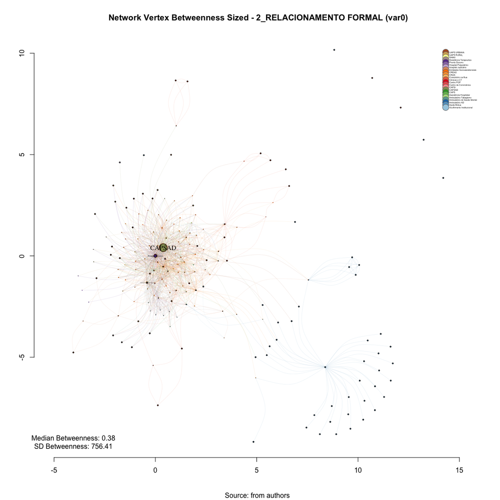

```r
set.seed(123)
#Plotting based only on degree measures
edge.start <- ends(var0, es=E(var0), names=F)[,1]

# Fixing ego
minC <- rep(-Inf, vcount(var0))
maxC <- rep(Inf, vcount(var0))
minC[1] <- maxC[1] <- 0
co <- layout_with_fr(var0, niter=10^4, minx=minC, maxx=maxC,miny=minC, maxy=maxC, weights = E(var0)$weight)

#Plotting
plot(var0,
     layout=co,
     edge.color=V(var0)$color[edge.start],
     edge.arrow.size=(betweenness(var0, weights = E(var0)$var0)+1)/100000,
     edge.width=E(var0)$weight/10*mean(E(var0)$weight),
     edge.curved = TRUE,
     vertex.color=V(var0)$color,
     vertex.size=betweenness(var0, weights = E(var0)$var0 )/250,
     vertex.frame.color="black",
     vertex.label.color="black",
     vertex.label=get.vertex.attribute(var0,"LABEL_COR"),
     vertex.label.cex=(betweenness(var0, weights = E(var0)$var0)+1)/10000,
     vertex.label.dist=0,
     rescale=F,
     xlim=range(co[,1]),
     ylim=range(co[,2])
     )
axis(1)
axis(2)

#Solving Problems with legend rendering
a<-V(var0)$LABEL_COR
b<-V(var0)$color
c<-table(a,b)
d<-as.data.frame(c)
e<-subset(d, d$Freq>0)
e<-e[order(e$a,decreasing=T),]
f<-t(e$a)
g<-t(e$b)

#Adding Legend
legend(x=range(co[,1])[2],
       y=range(co[,2])[2],
       legend=as.character(f),
       pch=21,
       col = "#777777",
       pt.bg=as.character(g),
       pt.cex=2,
       bty="n",
       ncol=1,
       lty=1,
       cex = .3)

#Adding Title
    title("Network Vertex Betweenness Sized - 2_RELACIONAMENTO FORMAL (var0)", sub = "Source: from authors ")
  text(
    x=range(co[,1])[1],
    y=range(co[,2])[1],
      labels =    sprintf("Median Betweenness: %.2f\nSD Betweenness: %.2f",
     median(betweenness(var0, weights = E(var0)$var0)),
     sd(betweenness(var0, weights = E(var0)$var0))
             )
       )
```

## 7.6 Network Plotting Based On Centralization Betweenness

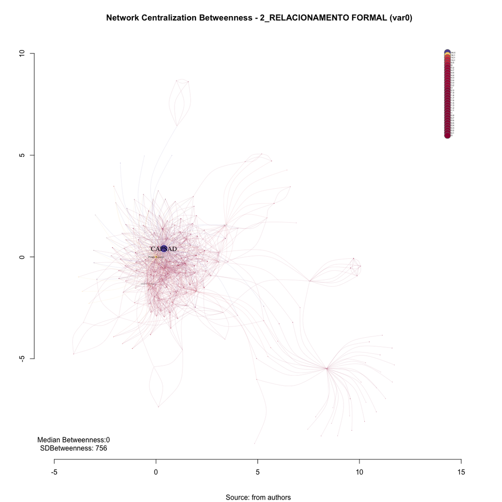

```r
#Get Variable
V(var0)$var0_centr_betweenness<-(centralization.betweenness(var0)$res)/100
V(var0)$var0_color_degree<-round(V(var0)$var0_centr_betweenness,1)

#Creating brewer pallette
vertex_var0_color_degree<-
  colorRampPalette(brewer.pal(length(unique(
          V(var0)$var0_color_degree)), "Spectral"))(
            length(unique(V(var0)$var0_color_degree)))

#Saving as Vertex properties
V(var0)$vertex_var0_color_degree<-
  vertex_var0_color_degree[as.numeric(
  cut(V(var0)$var0_color_degree,
      breaks=length(unique(V(var0)$var0_color_degree))))]

set.seed(123)
#Plotting based only on degree measures
edge.start <- ends(var0, es=E(var0), names=F)[,1]

# Fixing ego
minC <- rep(-Inf, vcount(var0))
maxC <- rep(Inf, vcount(var0))
minC[1] <- maxC[1] <- 0
co <- layout_with_fr(var0, niter=10^4, minx=minC, maxx=maxC,miny=minC, maxy=maxC, weights = E(var0)$weight)


#PLotting
plot(var0,
     layout=co,
     edge.color=V(var0)$vertex_var0_color_degree[edge.start],
     edge.arrow.size=closeness(var0, weights = E(var0)$var0, mode="out"),
     edge.width=E(var0)$weight/10*mean(E(var0)$weight),
     edge.curved = TRUE,
     vertex.color=V(var0)$vertex_var0_color_degree,
     vertex.size=(centralization.betweenness(var0)$res+1)/250,
     vertex.frame.color="white",
     vertex.label.color="black",
     vertex.label=get.vertex.attribute(var0,"LABEL_COR"),
     vertex.label.cex=(centralization.betweenness(var0)$res + 1)/10000,
     vertex.label.dist=0,
     rescale=F,
     xlim=range(co[,1]),
     ylim=range(co[,2])
     )
axis(1)
axis(2)

#Solving Problems with legend rendering
a<-V(var0)$var0_color_degree
b<-V(var0)$vertex_var0_color_degree
c<-table(a,b)
d<-as.data.frame(c)
e<-subset(d, d$Freq>0)
e<-e[order(e$a,decreasing=T),]
f<-t(e$a)
g<-t(e$b)

#Adding Legend
legend(x=range(co[,1])[2],
       y=range(co[,2])[2],
       legend=as.character(f),
       pch=21,
       col = "#777777",
       pt.bg=as.character(g),
       pt.cex=2,
       bty="n",
       ncol=1,
       lty=1,
       cex = .3)

  #Adding Title
  title("Network Centralization Betweenness - 2_RELACIONAMENTO FORMAL (var0)", sub = "Source: from authors ")
  text(
    x=range(co[,1])[1],
    y=range(co[,2])[1],
      labels = sprintf("Median Betweenness:%.0f\nSDBetweenness: %.0f",
     median(betweenness(var0, weights = E(var0)$var0)),
     sd(betweenness(var0, weights = E(var0)$var0))
             )
       )
```

# 8 Saving objects with new variables and changes

```r
save.image("~/SNArRDJF/Robject/var0_data.RData")
```